# Product_Data_01

Salami Zainab

2024-07-02

# 1 INSTALLING PACKAGES AND LOADING LIBRARIES

```r
library('kableExtra')
library('corrplot')
library('patchwork')
library('ggplot2')
library('dplyr')
library('fastDummies')
library('kableExtra')
library('gridExtra')
```

# 2 INTRODUCTION

In this project, I analyze historical sales data to predict future sales volumes for four product types: PCs, Laptops, Netbooks, and Smartphones. The goal is to provide insights into how these products perform against each other, while also assessing the impact of service and customer reviews on their sales.

Using regression techniques, I will apply and compare four machine learning algorithms (Brnn, RRF, GBM and Ranger) to determine the best model for accurate sales predictions. This analysis will help Blackwell Electronics better understand how product types influence sales and provide actionable insights for their sales strategy.

# 3 LOADING DATASET

```r
#loading the dataset from csv file
EP <- read.csv('existingproductattributes2017.csv')
NP <- read.csv('newproductattributes2017.csv')
```

##EP Dataset

##Checking for attributes for EP dataset

```r
attributes(EP)
```

```
## $names
##  [1] "ProductType"           "ProductNum"            "Price"
##  [4] "x5StarReviews"         "x4StarReviews"         "x3StarReviews"
##  [7] "x2StarReviews"         "x1StarReviews"         "PositiveServiceReview"
## [10] "NegativeServiceReview" "Recommendproduct"      "BestSellersRank"
## [13] "ShippingWeight"        "ProductDepth"          "ProductWidth"
## [16] "ProductHeight"         "ProfitMargin"          "Volume"
##
## $class
## [1] "data.frame"
##
## $row.names
##  [1]  1  2  3  4  5  6  7  8  9 10 11 12 13 14 15 16 17 18 19 20 21 22 23 24 25
## [26] 26 27 28 29 30 31 32 33 34 35 36 37 38 39 40 41 42 43 44 45 46 47 48 49 50
## [51] 51 52 53 54 55 56 57 58 59 60 61 62 63 64 65 66 67 68 69 70 71 72 73 74 75
## [76] 76 77 78 79 80
```

## 3.1 Checking the structure of EP

```r
str(EP)
```

```
## 'data.frame':    80 obs. of  18 variables:
##  $ ProductType          : chr  "PC" "PC" "PC" "Laptop" ...
##  $ ProductNum           : int  101 102 103 104 105 106 107 108 109 110 ...
##  $ Price                : num  949 2250 399 410 1080 ...
##  $ x5StarReviews        : int  3 2 3 49 58 83 11 33 16 10 ...
##  $ x4StarReviews        : int  3 1 0 19 31 30 3 19 9 1 ...
##  $ x3StarReviews        : int  2 0 0 8 11 10 0 12 2 1 ...
##  $ x2StarReviews        : int  0 0 0 3 7 9 0 5 0 0 ...
##  $ x1StarReviews        : int  0 0 0 9 36 40 1 9 2 0 ...
##  $ PositiveServiceReview: int  2 1 1 7 7 12 3 5 2 2 ...
##  $ NegativeServiceReview: int  0 0 0 8 20 5 0 3 1 0 ...
##  $ Recommendproduct     : num  0.9 0.9 0.9 0.8 0.7 0.3 0.9 0.7 0.8 0.9 ...
##  $ BestSellersRank      : int  1967 4806 12076 109 268 64 NA 2 NA 18 ...
##  $ ShippingWeight       : num  25.8 50 17.4 5.7 7 1.6 7.3 12 1.8 0.75 ...
##  $ ProductDepth         : num  23.9 35 10.5 15 12.9 ...
##  $ ProductWidth         : num  6.62 31.75 8.3 9.9 0.3 ...
##  $ ProductHeight        : num  16.9 19 10.2 1.3 8.9 ...
##  $ ProfitMargin         : num  0.15 0.25 0.08 0.08 0.09 0.05 0.05 0.05 0.05 0.05 ...
##  $ Volume               : int  12 8 12 196 232 332 44 132 64 40 ...
```

## 3.2 Checking the summary of EP

```r
summary(EP)
```

```
##  ProductType          ProductNum        Price         x5StarReviews
##  Length:80          Min.   :101.0   Min.   :   3.60   Min.   :   0.0
##  Class :character   1st Qu.:120.8   1st Qu.:  52.66   1st Qu.:  10.0
##  Mode  :character   Median :140.5   Median : 132.72   Median :  50.0
##                     Mean   :142.6   Mean   : 247.25   Mean   : 176.2
##                     3rd Qu.:160.2   3rd Qu.: 352.49   3rd Qu.: 306.5
##                     Max.   :200.0   Max.   :2249.99   Max.   :2801.0
##
##  x4StarReviews    x3StarReviews    x2StarReviews    x1StarReviews
##  Min.   :  0.00   Min.   :  0.00   Min.   :  0.00   Min.   :   0.00
##  1st Qu.:  2.75   1st Qu.:  2.00   1st Qu.:  1.00   1st Qu.:   2.00
##  Median : 22.00   Median :  7.00   Median :  3.00   Median :   8.50
##  Mean   : 40.20   Mean   : 14.79   Mean   : 13.79   Mean   :  37.67
##  3rd Qu.: 33.00   3rd Qu.: 11.25   3rd Qu.:  7.00   3rd Qu.:  15.25
##  Max.   :431.00   Max.   :162.00   Max.   :370.00   Max.   :1654.00
##
##  PositiveServiceReview NegativeServiceReview Recommendproduct BestSellersRank
##  Min.   :  0.00        Min.   :  0.000       Min.   :0.100    Min.   :    1
##  1st Qu.:  2.00        1st Qu.:  1.000       1st Qu.:0.700    1st Qu.:    7
##  Median :  5.50        Median :  3.000       Median :0.800    Median :   27
##  Mean   : 51.75        Mean   :  6.225       Mean   :0.745    Mean   : 1126
##  3rd Qu.: 42.00        3rd Qu.:  6.250       3rd Qu.:0.900    3rd Qu.:  281
##  Max.   :536.00        Max.   :112.000       Max.   :1.000    Max.   :17502
##                                                               NA's   :15
##  ShippingWeight     ProductDepth      ProductWidth    ProductHeight
##  Min.   : 0.0100   Min.   :  0.000   Min.   : 0.000   Min.   : 0.000
##  1st Qu.: 0.5125   1st Qu.:  4.775   1st Qu.: 1.750   1st Qu.: 0.400
##  Median : 2.1000   Median :  7.950   Median : 6.800   Median : 3.950
##  Mean   : 9.6681   Mean   : 14.425   Mean   : 7.819   Mean   : 6.259
##  3rd Qu.:11.2050   3rd Qu.: 15.025   3rd Qu.:11.275   3rd Qu.:10.300
##  Max.   :63.0000   Max.   :300.000   Max.   :31.750   Max.   :25.800
##
##   ProfitMargin        Volume
##  Min.   :0.0500   Min.   :    0
##  1st Qu.:0.0500   1st Qu.:   40
##  Median :0.1200   Median :  200
##  Mean   :0.1545   Mean   :  705
##  3rd Qu.:0.2000   3rd Qu.: 1226
##  Max.   :0.4000   Max.   :11204
##
```

#DATA PREPROCESSING/DATA PREPARATION ##Checking for Duplicates

```r
duplicating <- EP[duplicated(EP), ]
duplicating
```

```
##  [1] ProductType           ProductNum            Price
##  [4] x5StarReviews         x4StarReviews         x3StarReviews
##  [7] x2StarReviews         x1StarReviews         PositiveServiceReview
## [10] NegativeServiceReview Recommendproduct      BestSellersRank
## [13] ShippingWeight        ProductDepth          ProductWidth
## [16] ProductHeight         ProfitMargin          Volume
## <0 rows> (or 0-length row.names)
```

*I observed that there are no duplicates in the dataset ##Checking for Missing Values

```r
colSums(is.na(EP))
```

```
##           ProductType            ProductNum                 Price
##                     0                     0                     0
##         x5StarReviews         x4StarReviews         x3StarReviews
##                     0                     0                     0
##         x2StarReviews         x1StarReviews PositiveServiceReview
##                     0                     0                     0
## NegativeServiceReview      Recommendproduct       BestSellersRank
##                     0                     0                    15
##        ShippingWeight          ProductDepth          ProductWidth
##                     0                     0                     0
##         ProductHeight          ProfitMargin                Volume
##                     0                     0                     0
```

*I observed there are 15 NA’s in the BestSellersRank

##Replace NA values in BestSellersRank with 0

```r
EP_NA_BestSellers <- EP %>%
  mutate(BestSellersRank = ifelse(is.na(BestSellersRank), 0, BestSellersRank))
```

## 3.3 NP Dataset

## 3.4 Displaying the attributes of NP

```r
attributes(NP)
```

```
## $names
##  [1] "ProductType"           "ProductNum"            "Price"
##  [4] "x5StarReviews"         "x4StarReviews"         "x3StarReviews"
##  [7] "x2StarReviews"         "x1StarReviews"         "PositiveServiceReview"
## [10] "NegativeServiceReview" "Recommendproduct"      "BestSellersRank"
## [13] "ShippingWeight"        "ProductDepth"          "ProductWidth"
## [16] "ProductHeight"         "ProfitMargin"          "Volume"
##
## $class
## [1] "data.frame"
##
## $row.names
##  [1]  1  2  3  4  5  6  7  8  9 10 11 12 13 14 15 16 17 18 19 20 21 22 23 24
```

## 3.5 Displaying the structure of NP

```r
str(NP)
```

```
## 'data.frame':    24 obs. of  18 variables:
##  $ ProductType          : chr  "PC" "PC" "Laptop" "Laptop" ...
##  $ ProductNum           : int  171 172 173 175 176 178 180 181 183 186 ...
##  $ Price                : num  699 860 1199 1199 1999 ...
##  $ x5StarReviews        : int  96 51 74 7 1 19 312 23 3 296 ...
##  $ x4StarReviews        : int  26 11 10 2 1 8 112 18 4 66 ...
##  $ x3StarReviews        : int  14 10 3 1 1 4 28 7 0 30 ...
##  $ x2StarReviews        : int  14 10 3 1 3 1 31 22 1 21 ...
##  $ x1StarReviews        : int  25 21 11 1 0 10 47 18 0 36 ...
##  $ PositiveServiceReview: int  12 7 11 2 0 2 28 5 1 28 ...
##  $ NegativeServiceReview: int  3 5 5 1 1 4 16 16 0 9 ...
##  $ Recommendproduct     : num  0.7 0.6 0.8 0.6 0.3 0.6 0.7 0.4 0.7 0.8 ...
##  $ BestSellersRank      : int  2498 490 111 4446 2820 4140 2699 1704 5128 34 ...
##  $ ShippingWeight       : num  19.9 27 6.6 13 11.6 5.8 4.6 4.8 4.3 3 ...
##  $ ProductDepth         : num  20.63 21.89 8.94 16.3 16.81 ...
##  $ ProductWidth         : num  19.2 27 12.8 10.8 10.9 ...
##  $ ProductHeight        : num  8.39 9.13 0.68 1.4 0.88 1.2 0.95 1.5 0.97 0.37 ...
##  $ ProfitMargin         : num  0.25 0.2 0.1 0.15 0.23 0.08 0.09 0.11 0.09 0.1 ...
##  $ Volume               : int  0 0 0 0 0 0 0 0 0 0 ...
```

## 3.6 Displaying the summary of NP

```r
summary(NP)
```

```
##  ProductType          ProductNum        Price        x5StarReviews
##  Length:24          Min.   :171.0   Min.   :   8.5   Min.   :   0.00
##  Class :character   1st Qu.:179.5   1st Qu.: 130.0   1st Qu.:  16.00
##  Mode  :character   Median :193.5   Median : 275.0   Median :  46.00
##                     Mean   :219.5   Mean   : 425.6   Mean   : 178.50
##                     3rd Qu.:301.2   3rd Qu.: 486.5   3rd Qu.:  99.25
##                     Max.   :307.0   Max.   :1999.0   Max.   :1525.00
##  x4StarReviews    x3StarReviews    x2StarReviews    x1StarReviews
##  Min.   :  0.00   Min.   :  0.00   Min.   :  0.00   Min.   :  0.00
##  1st Qu.:  2.00   1st Qu.:  1.75   1st Qu.:  1.00   1st Qu.:  1.75
##  Median : 10.50   Median :  4.50   Median :  4.00   Median : 13.00
##  Mean   : 48.04   Mean   : 21.92   Mean   : 17.50   Mean   : 27.58
##  3rd Qu.: 26.00   3rd Qu.: 16.75   3rd Qu.: 20.25   3rd Qu.: 35.25
##  Max.   :437.00   Max.   :224.00   Max.   :160.00   Max.   :247.00
##  PositiveServiceReview NegativeServiceReview Recommendproduct
##  Min.   : 0.00         Min.   : 0.000        Min.   :0.3000
##  1st Qu.: 2.00         1st Qu.: 1.000        1st Qu.:0.6000
##  Median : 5.00         Median : 3.500        Median :0.7000
##  Mean   :13.46         Mean   : 5.667        Mean   :0.6708
##  3rd Qu.:12.50         3rd Qu.: 7.500        3rd Qu.:0.8000
##  Max.   :90.00         Max.   :23.000        Max.   :1.0000
##  BestSellersRank    ShippingWeight    ProductDepth     ProductWidth
##  Min.   :    1.00   Min.   : 0.200   Min.   : 0.000   Min.   : 0.000
##  1st Qu.:   93.25   1st Qu.: 0.900   1st Qu.: 5.225   1st Qu.: 5.832
##  Median :  750.50   Median : 4.450   Median : 8.000   Median : 9.950
##  Mean   : 3957.62   Mean   : 7.802   Mean   : 9.094   Mean   :10.408
##  3rd Qu.: 3150.00   3rd Qu.: 9.575   3rd Qu.:11.425   3rd Qu.:12.875
##  Max.   :44465.00   Max.   :42.000   Max.   :21.890   Max.   :27.010
##  ProductHeight     ProfitMargin        Volume
##  Min.   : 0.000   Min.   :0.0500   Min.   :0
##  1st Qu.: 0.400   1st Qu.:0.0975   1st Qu.:0
##  Median : 0.985   Median :0.1150   Median :0
##  Mean   : 3.541   Mean   :0.1817   Mean   :0
##  3rd Qu.: 2.888   3rd Qu.:0.2000   3rd Qu.:0
##  Max.   :25.800   Max.   :0.9000   Max.   :0
```

## 3.7 Displaying the column headers of NP

```r
head(NP)
```

```
##   ProductType ProductNum   Price x5StarReviews x4StarReviews x3StarReviews
## 1          PC        171  699.00            96            26            14
## 2          PC        172  860.00            51            11            10
## 3      Laptop        173 1199.00            74            10             3
## 4      Laptop        175 1199.00             7             2             1
## 5      Laptop        176 1999.00             1             1             1
## 6     Netbook        178  399.99            19             8             4
##   x2StarReviews x1StarReviews PositiveServiceReview NegativeServiceReview
## 1            14            25                    12                     3
## 2            10            21                     7                     5
## 3             3            11                    11                     5
## 4             1             1                     2                     1
## 5             3             0                     0                     1
## 6             1            10                     2                     4
##   Recommendproduct BestSellersRank ShippingWeight ProductDepth ProductWidth
## 1              0.7            2498           19.9        20.63        19.25
## 2              0.6             490           27.0        21.89        27.01
## 3              0.8             111            6.6         8.94        12.80
## 4              0.6            4446           13.0        16.30        10.80
## 5              0.3            2820           11.6        16.81        10.90
## 6              0.6            4140            5.8         8.43        11.42
##   ProductHeight ProfitMargin Volume
## 1          8.39         0.25      0
## 2          9.13         0.20      0
## 3          0.68         0.10      0
## 4          1.40         0.15      0
## 5          0.88         0.23      0
## 6          1.20         0.08      0
```

```r
NP_V1 <- NP[-c(4,5,7,10,12,18)]
```

*The above statistical distribution shows that the variables not needed have been removed.

## 3.8 Displaying structure of NP_V1

```r
str(NP_V1)
```

```
## 'data.frame':    24 obs. of  12 variables:
##  $ ProductType          : chr  "PC" "PC" "Laptop" "Laptop" ...
##  $ ProductNum           : int  171 172 173 175 176 178 180 181 183 186 ...
##  $ Price                : num  699 860 1199 1199 1999 ...
##  $ x3StarReviews        : int  14 10 3 1 1 4 28 7 0 30 ...
##  $ x1StarReviews        : int  25 21 11 1 0 10 47 18 0 36 ...
##  $ PositiveServiceReview: int  12 7 11 2 0 2 28 5 1 28 ...
##  $ Recommendproduct     : num  0.7 0.6 0.8 0.6 0.3 0.6 0.7 0.4 0.7 0.8 ...
##  $ ShippingWeight       : num  19.9 27 6.6 13 11.6 5.8 4.6 4.8 4.3 3 ...
##  $ ProductDepth         : num  20.63 21.89 8.94 16.3 16.81 ...
##  $ ProductWidth         : num  19.2 27 12.8 10.8 10.9 ...
##  $ ProductHeight        : num  8.39 9.13 0.68 1.4 0.88 1.2 0.95 1.5 0.97 0.37 ...
##  $ ProfitMargin         : num  0.25 0.2 0.1 0.15 0.23 0.08 0.09 0.11 0.09 0.1 ...
```

## 3.9 Checking for Samples

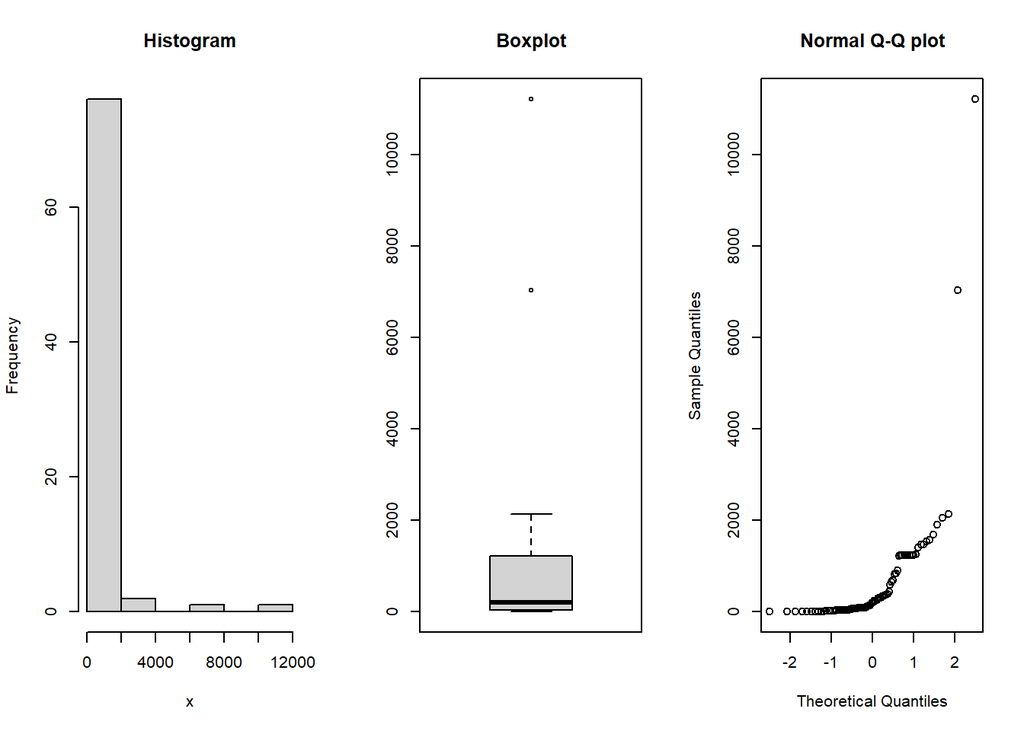

```r
x = EP$Volume
#histogram, Q-Q plot, and boxplot
par(mfrow = c(1, 3))
hist(x, main = "Histogram")
boxplot(x, main = "Boxplot")
qqnorm(x, main = "Normal Q-Q plot")
```

Checking samples we observed that the outliers are associated with Accessories and Game Console which are not part of our target Product Type and constitute about 2.5 percent of our entire dataset, we would therefore delete these two observations.

```r
##Deleting the 50th and 73rd rows that contain outliers
EP_No_Outlier_No_Volume <- EP[-c(50,73), ]
head(EP_No_Outlier_No_Volume)
```

```
##   ProductType ProductNum   Price x5StarReviews x4StarReviews x3StarReviews
## 1          PC        101  949.00             3             3             2
## 2          PC        102 2249.99             2             1             0
## 3          PC        103  399.00             3             0             0
## 4      Laptop        104  409.99            49            19             8
## 5      Laptop        105 1079.99            58            31            11
## 6 Accessories        106  114.22            83            30            10
##   x2StarReviews x1StarReviews PositiveServiceReview NegativeServiceReview
## 1             0             0                     2                     0
## 2             0             0                     1                     0
## 3             0             0                     1                     0
## 4             3             9                     7                     8
## 5             7            36                     7                    20
## 6             9            40                    12                     5
##   Recommendproduct BestSellersRank ShippingWeight ProductDepth ProductWidth
## 1              0.9            1967           25.8        23.94         6.62
## 2              0.9            4806           50.0        35.00        31.75
## 3              0.9           12076           17.4        10.50         8.30
## 4              0.8             109            5.7        15.00         9.90
## 5              0.7             268            7.0        12.90         0.30
## 6              0.3              64            1.6         5.80         4.00
##   ProductHeight ProfitMargin Volume
## 1         16.89         0.15     12
## 2         19.00         0.25      8
## 3         10.20         0.08     12
## 4          1.30         0.08    196
## 5          8.90         0.09    232
## 6          1.00         0.05    332
```

We look at the summary

```r
summary(EP_No_Outlier_No_Volume$Volume)
```

```
##    Min. 1st Qu.  Median    Mean 3rd Qu.    Max.
##     0.0    40.0   166.0   489.2   887.0  2140.0
```

We dumify the ProductType to convert a categorical variable with different categories referring to different classes of the ProductType to variables that are actually boolean varables telling me if these variables are true or false

```r
EP_existing_copy_process <- dummy_cols(EP_No_Outlier_No_Volume, select_columns = 'ProductType')
```

This is the table that contains the Product Type and the volume

```r
EP_volume_copy <- EP_No_Outlier_No_Volume[, -c(2,3,4,5,6,7,8,9,10,11,12,13,14,15,16,17)]
head(EP_volume_copy)
```

```
##   ProductType Volume
## 1          PC     12
## 2          PC      8
## 3          PC     12
## 4      Laptop    196
## 5      Laptop    232
## 6 Accessories    332
```

```r
kable(EP_volume_copy) %>%
#kable(digits = 0)
kable_styling(bootstrap_options = c("striped", "hover", "condensed", "responsive"), fixed_thead = T)
```

|  | ProductType | Volume |
| --- | --- | --- |
| 1 | PC | 12 |
| 2 | PC | 8 |
| 3 | PC | 12 |
| 4 | Laptop | 196 |
| 5 | Laptop | 232 |
| 6 | Accessories | 332 |
| 7 | Accessories | 44 |
| 8 | Accessories | 132 |
| 9 | Accessories | 64 |
| 10 | Accessories | 40 |
| 11 | Accessories | 84 |
| 12 | Accessories | 300 |
| 13 | Accessories | 40 |
| 14 | Accessories | 1252 |
| 15 | Accessories | 1396 |
| 16 | Accessories | 32 |
| 17 | Accessories | 44 |
| 18 | Accessories | 680 |
| 19 | Accessories | 60 |
| 20 | Software | 80 |
| 21 | Software | 136 |
| 22 | Software | 1576 |
| 23 | Software | 2052 |
| 24 | Software | 116 |
| 25 | Software | 308 |
| 26 | Display | 1224 |
| 27 | Printer | 32 |
| 28 | Printer | 88 |
| 29 | PrinterSupplies | 0 |
| 30 | PrinterSupplies | 24 |
| 31 | PrinterSupplies | 20 |
| 32 | ExtendedWarranty | 0 |
| 33 | ExtendedWarranty | 20 |
| 34 | ExtendedWarranty | 1232 |
| 35 | ExtendedWarranty | 1232 |
| 36 | ExtendedWarranty | 1232 |
| 37 | ExtendedWarranty | 1232 |
| 38 | ExtendedWarranty | 1232 |
| 39 | ExtendedWarranty | 1232 |
| 40 | ExtendedWarranty | 1232 |
| 41 | ExtendedWarranty | 1232 |
| 42 | PC | 84 |
| 43 | Laptop | 88 |
| 44 | Accessories | 368 |
| 45 | Accessories | 1536 |
| 46 | Accessories | 1464 |
| 47 | Accessories | 836 |
| 48 | Accessories | 2140 |
| 49 | Accessories | 52 |
| 51 | Accessories | 12 |
| 52 | Accessories | 204 |
| 53 | Accessories | 1896 |
| 54 | Accessories | 432 |
| 55 | Accessories | 904 |
| 56 | Display | 360 |
| 57 | Display | 656 |
| 58 | Display | 104 |
| 59 | Display | 84 |
| 60 | Printer | 296 |
| 61 | Printer | 232 |
| 62 | Printer | 16 |
| 63 | Printer | 32 |
| 64 | Printer | 8 |
| 65 | Printer | 80 |
| 66 | Printer | 0 |
| 67 | Printer | 824 |
| 68 | Printer | 32 |
| 69 | Printer | 396 |
| 70 | Netbook | 4 |
| 71 | Tablet | 592 |
| 72 | Smartphone | 16 |
| 74 | Tablet | 344 |
| 75 | Tablet | 12 |
| 76 | Smartphone | 248 |
| 77 | Smartphone | 72 |
| 78 | Netbook | 88 |
| 79 | Smartphone | 1472 |
| 80 | GameConsole | 1684 |

```r
EP_volume_copy %>%
  group_by(ProductType) %>%
  summarise(Volume = sum(Volume))
```

```
## # A tibble: 12 × 2
##    ProductType      Volume
##    <chr>             <int>
##  1 Accessories       14344
##  2 Display            2428
##  3 ExtendedWarranty   9876
##  4 GameConsole        1684
##  5 Laptop              516
##  6 Netbook              92
##  7 PC                  116
##  8 Printer            2036
##  9 PrinterSupplies      44
## 10 Smartphone         1808
## 11 Software           4268
## 12 Tablet              948
```

```r
EP_existing_copy_process_cor<- EP_existing_copy_process[, -c(1)]
```

```r
str(EP_existing_copy_process_cor)
```

```
## 'data.frame':    78 obs. of  29 variables:
##  $ ProductNum                  : int  101 102 103 104 105 106 107 108 109 110 ...
##  $ Price                       : num  949 2250 399 410 1080 ...
##  $ x5StarReviews               : int  3 2 3 49 58 83 11 33 16 10 ...
##  $ x4StarReviews               : int  3 1 0 19 31 30 3 19 9 1 ...
##  $ x3StarReviews               : int  2 0 0 8 11 10 0 12 2 1 ...
##  $ x2StarReviews               : int  0 0 0 3 7 9 0 5 0 0 ...
##  $ x1StarReviews               : int  0 0 0 9 36 40 1 9 2 0 ...
##  $ PositiveServiceReview       : int  2 1 1 7 7 12 3 5 2 2 ...
##  $ NegativeServiceReview       : int  0 0 0 8 20 5 0 3 1 0 ...
##  $ Recommendproduct            : num  0.9 0.9 0.9 0.8 0.7 0.3 0.9 0.7 0.8 0.9 ...
##  $ BestSellersRank             : int  1967 4806 12076 109 268 64 NA 2 NA 18 ...
##  $ ShippingWeight              : num  25.8 50 17.4 5.7 7 1.6 7.3 12 1.8 0.75 ...
##  $ ProductDepth                : num  23.9 35 10.5 15 12.9 ...
##  $ ProductWidth                : num  6.62 31.75 8.3 9.9 0.3 ...
##  $ ProductHeight               : num  16.9 19 10.2 1.3 8.9 ...
##  $ ProfitMargin                : num  0.15 0.25 0.08 0.08 0.09 0.05 0.05 0.05 0.05 0.05 ...
##  $ Volume                      : int  12 8 12 196 232 332 44 132 64 40 ...
##  $ ProductType_Accessories     : int  0 0 0 0 0 1 1 1 1 1 ...
##  $ ProductType_Display         : int  0 0 0 0 0 0 0 0 0 0 ...
##  $ ProductType_ExtendedWarranty: int  0 0 0 0 0 0 0 0 0 0 ...
##  $ ProductType_GameConsole     : int  0 0 0 0 0 0 0 0 0 0 ...
##  $ ProductType_Laptop          : int  0 0 0 1 1 0 0 0 0 0 ...
##  $ ProductType_Netbook         : int  0 0 0 0 0 0 0 0 0 0 ...
##  $ ProductType_PC              : int  1 1 1 0 0 0 0 0 0 0 ...
##  $ ProductType_Printer         : int  0 0 0 0 0 0 0 0 0 0 ...
##  $ ProductType_PrinterSupplies : int  0 0 0 0 0 0 0 0 0 0 ...
##  $ ProductType_Smartphone      : int  0 0 0 0 0 0 0 0 0 0 ...
##  $ ProductType_Software        : int  0 0 0 0 0 0 0 0 0 0 ...
##  $ ProductType_Tablet          : int  0 0 0 0 0 0 0 0 0 0 ...
```

The above statistical distribution shows that the outliers have been removed.

```r
EP_Product <- EP_existing_copy_process_cor[, -c(2,3,4,5,6,7,8,9,10,11,12,13,14,15,16,17,19,20,21,22,23,24,25,26,27,28,29,18)]
```

On another variable created we also dropped some variables as a result of collinearlity and variable importance of the predictors to avoid over fitting in our Model

```r
EP_Reorder <- EP_existing_copy_process_cor[, -c(1,2,4,6,9,10,11,12,13,14,15,16,17,18,19,20,21,22,23,24,25,26,27,28,29,30)]
```

```r
EP_Reorder
```

```
##    x5StarReviews x3StarReviews x1StarReviews PositiveServiceReview
## 1              3             2             0                     2
## 2              2             0             0                     1
## 3              3             0             0                     1
## 4             49             8             9                     7
## 5             58            11            36                     7
## 6             83            10            40                    12
## 7             11             0             1                     3
## 8             33            12             9                     5
## 9             16             2             2                     2
## 10            10             1             0                     2
## 11            21             2            15                     2
## 12            75             6             3                     9
## 13            10             5             1                     2
## 14           313            13            16                    44
```

[output cut: 64 more lines]

```r
str(EP_existing_copy_process)
```

```
## 'data.frame':    78 obs. of  30 variables:
##  $ ProductType                 : chr  "PC" "PC" "PC" "Laptop" ...
##  $ ProductNum                  : int  101 102 103 104 105 106 107 108 109 110 ...
##  $ Price                       : num  949 2250 399 410 1080 ...
##  $ x5StarReviews               : int  3 2 3 49 58 83 11 33 16 10 ...
##  $ x4StarReviews               : int  3 1 0 19 31 30 3 19 9 1 ...
##  $ x3StarReviews               : int  2 0 0 8 11 10 0 12 2 1 ...
##  $ x2StarReviews               : int  0 0 0 3 7 9 0 5 0 0 ...
##  $ x1StarReviews               : int  0 0 0 9 36 40 1 9 2 0 ...
##  $ PositiveServiceReview       : int  2 1 1 7 7 12 3 5 2 2 ...
##  $ NegativeServiceReview       : int  0 0 0 8 20 5 0 3 1 0 ...
##  $ Recommendproduct            : num  0.9 0.9 0.9 0.8 0.7 0.3 0.9 0.7 0.8 0.9 ...
##  $ BestSellersRank             : int  1967 4806 12076 109 268 64 NA 2 NA 18 ...
##  $ ShippingWeight              : num  25.8 50 17.4 5.7 7 1.6 7.3 12 1.8 0.75 ...
##  $ ProductDepth                : num  23.9 35 10.5 15 12.9 ...
```

[output cut: 16 more lines]

## 3.10 Correlation Matrix to select the most important variables

```r
library(corrplot)
corrData <- cor(EP_existing_copy_process_cor)
```

[figure not shown]

```r
M = cor(corrData)

corrplot(M, method = 'number', number.digits = 2, tl.cex = 0.5, number.cex = 0.4, addCoef.col = 0.1)
```

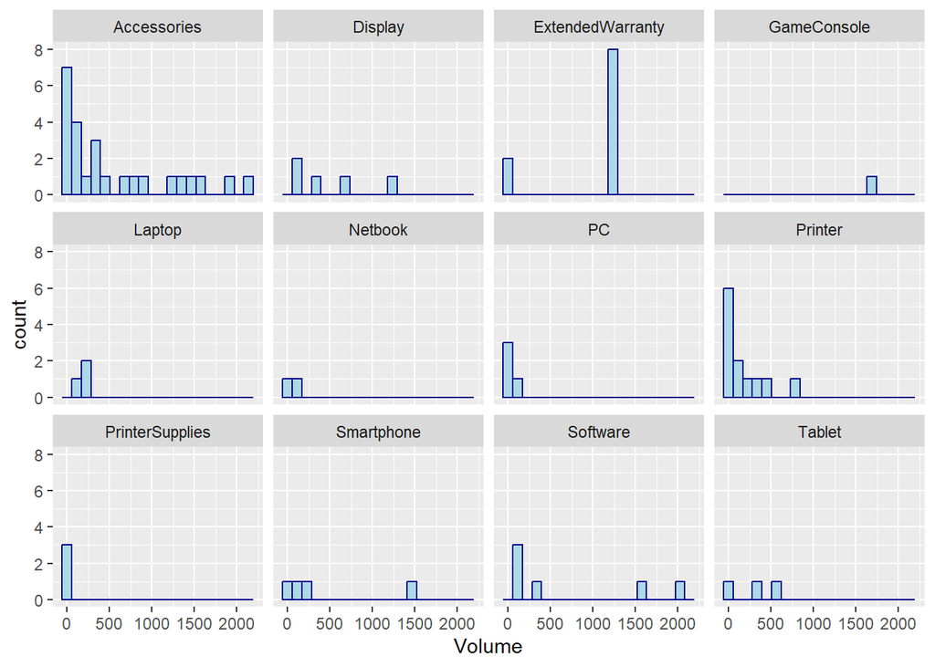

```r
# Histogram of Different Product Type with respect to Volume
ggplot(EP_No_Outlier_No_Volume, aes(x=Volume)) + geom_histogram(color='darkblue', fill='lightblue', bins=20 ) + facet_wrap(~ProductType)
```

Bivariate Analysis: We check for relationship between the most important attributes with respect to Volume

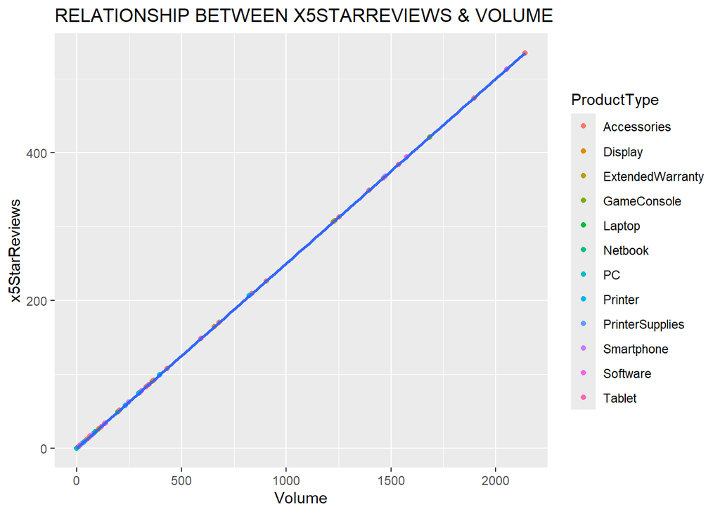

```r
ggplot(EP_No_Outlier_No_Volume) + geom_point(aes(y=x5StarReviews, x=Volume, col=ProductType)) + geom_smooth(method = "lm", se=FALSE, aes(y=x5StarReviews, x=Volume)) + labs(title= "RELATIONSHIP BETWEEN X5STARREVIEWS & VOLUME")
```

```r
##Deleting the 23rd and 48th rows that contain outliers
EP_x3StarReviews <- EP_No_Outlier_No_Volume[-c(23,48), ]
```

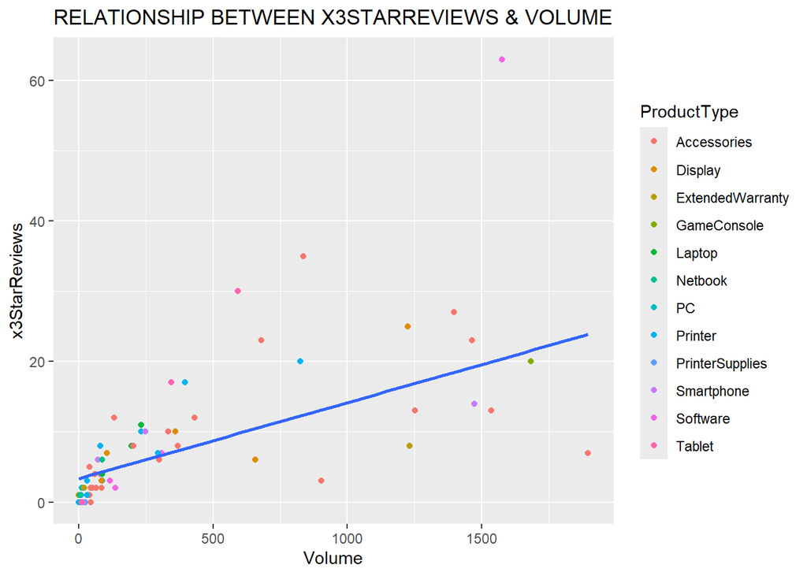

```r
ggplot(EP_x3StarReviews) + geom_point(aes(y=x3StarReviews, x=Volume, col=ProductType)) + geom_smooth(method = "lm", se=FALSE, aes(y=x3StarReviews, x=Volume)) + labs(title= "RELATIONSHIP BETWEEN X3STARREVIEWS & VOLUME")
```

```r
##Deleting the 34th and 46th rows that contain outliers
EP_Reviews <- EP_No_Outlier_No_Volume[-c(34,46), ]
```

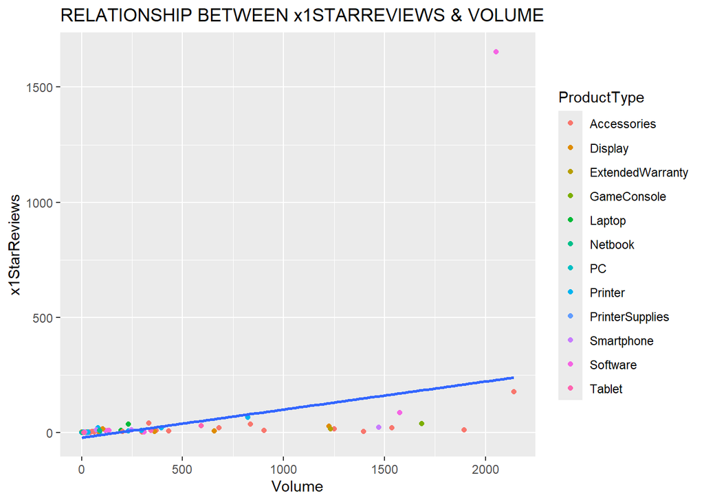

```r
ggplot(EP_Reviews) + geom_point(aes(y=x1StarReviews, x=Volume, col=ProductType)) + geom_smooth(method = "lm", se=FALSE, aes(y=x1StarReviews, x=Volume)) + labs(title= "RELATIONSHIP BETWEEN x1STARREVIEWS & VOLUME")
```

```r
##Deleting the 34th and 46th rows that contain outliers
EP_PositiveReviews <- EP_No_Outlier_No_Volume[-c(48), ]
```

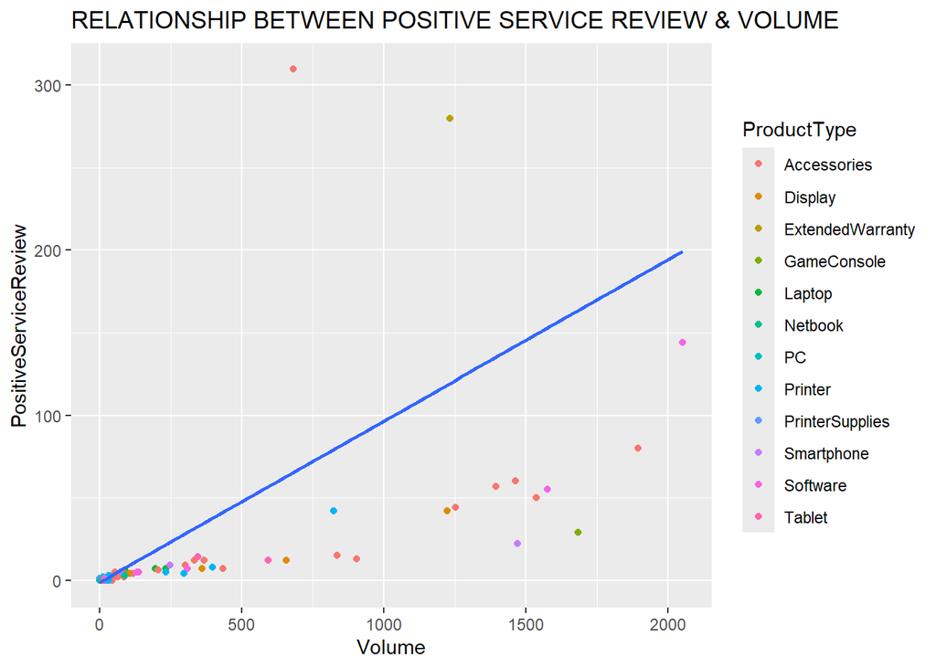

```r
ggplot(EP_PositiveReviews) + geom_point(aes(y=PositiveServiceReview, x=Volume, col=ProductType)) + geom_smooth(method = "lm", se=FALSE, aes(y=PositiveServiceReview, x=Volume)) + labs(title= "RELATIONSHIP BETWEEN POSITIVE SERVICE REVIEW & VOLUME")
```

##FEATURE SELECTION

```r
EP_Process_Model <- EP_existing_copy_process_cor[ -c(3,4,6,9,11,18,19,20,21,22,23,24,25,26,27,28,29)]
```

```r
str(EP_Process_Model)
```

```
## 'data.frame':    78 obs. of  12 variables:
##  $ ProductNum           : int  101 102 103 104 105 106 107 108 109 110 ...
##  $ Price                : num  949 2250 399 410 1080 ...
##  $ x3StarReviews        : int  2 0 0 8 11 10 0 12 2 1 ...
##  $ x1StarReviews        : int  0 0 0 9 36 40 1 9 2 0 ...
##  $ PositiveServiceReview: int  2 1 1 7 7 12 3 5 2 2 ...
##  $ Recommendproduct     : num  0.9 0.9 0.9 0.8 0.7 0.3 0.9 0.7 0.8 0.9 ...
##  $ ShippingWeight       : num  25.8 50 17.4 5.7 7 1.6 7.3 12 1.8 0.75 ...
##  $ ProductDepth         : num  23.9 35 10.5 15 12.9 ...
##  $ ProductWidth         : num  6.62 31.75 8.3 9.9 0.3 ...
##  $ ProductHeight        : num  16.9 19 10.2 1.3 8.9 ...
##  $ ProfitMargin         : num  0.15 0.25 0.08 0.08 0.09 0.05 0.05 0.05 0.05 0.05 ...
##  $ Volume               : int  12 8 12 196 232 332 44 132 64 40 ...
```

```r
library(caret)
set.seed(107)
inTrain <- createDataPartition(
EP_Process_Model$Volume, p = .75, list = FALSE
## The outcome data are needed
## The percentage of data in the training set
)
training <- EP_Process_Model[inTrain,]
testing <- EP_Process_Model[-inTrain,]
nrow(training)
```

```
## [1] 60
```

```r
nrow(testing)
```

```
## [1] 18
```

# 4 MODELLING

## 4.1 We started building the Model using Ranger, Gradient Boosting, Bayesian Regularized Neural Networks, and Regularized Random Forest

##Ranger

```r
ctrl <- trainControl(
method = "repeatedcv", number = 5,
repeats = 1
)
set.seed(123)
Ranger_Volume <- train(Volume ~ .,
  data = training,
  method = "ranger",
  preProc = c("center", "scale"),
  tuneLength = 5,
  trControl = ctrl

)
save(file = 'Ranger_Volume.rdata')
```

```r
Ranger_Volume
```

```
## Random Forest
##
## 60 samples
## 11 predictors
##
## Pre-processing: centered (11), scaled (11)
## Resampling: Cross-Validated (5 fold, repeated 1 times)
## Summary of sample sizes: 48, 49, 48, 47, 48
## Resampling results across tuning parameters:
##
##   mtry  splitrule   RMSE      Rsquared   MAE
##    2    variance    296.1447  0.8045590  199.3741
##    2    extratrees  318.1891  0.8145530  223.3510
##    4    variance    267.5815  0.8204445  163.6136
##    4    extratrees  276.1703  0.8377270  181.8640
##    6    variance    258.2942  0.8299486  146.9917
##    6    extratrees  263.8423  0.8400814  167.2782
##    8    variance    247.2861  0.8492974  139.2093
##    8    extratrees  253.2008  0.8438066  153.7522
##   11    variance    233.8225  0.8656561  128.4917
##   11    extratrees  244.6084  0.8485872  142.1624
##
## Tuning parameter 'min.node.size' was held constant at a value of 5
## RMSE was used to select the optimal model using the smallest value.
## The final values used for the model were mtry = 11, splitrule = variance
##  and min.node.size = 5.
```

```r
Ranger_Volume_predict <- predict(Ranger_Volume,testing)
```

```r
str(testing$Volume)
```

```
##  int [1:18] 12 232 64 40 40 1396 2052 116 308 88 ...
```

##Bayesian Regularized Neural Networks

```r
set.seed(123)
Brnn_Volume <- train(Volume ~ .,
  data = training,
  method = "brnn",
  preProc = c("center", "scale"),
  tuneLength = 5,
  trControl = ctrl

)
```

[output not shown]

[output cut: 49 more lines]

[output not shown]

```r
save(file = 'brnn_Volume.rdata')
```

```r
Brnn_Volume
```

```
## Bayesian Regularized Neural Networks
##
## 60 samples
## 11 predictors
##
## Pre-processing: centered (11), scaled (11)
## Resampling: Cross-Validated (5 fold, repeated 1 times)
## Summary of sample sizes: 48, 49, 48, 47, 48
## Resampling results across tuning parameters:
##
##   neurons  RMSE      Rsquared   MAE
##   1        366.4514  0.6850163  231.5805
##   2        399.2114  0.7650905  272.9514
##   3        356.9052  0.7393034  232.0087
##   4        359.3095  0.6426414  251.6847
##   5        392.2055  0.6284788  251.8051
##
## RMSE was used to select the optimal model using the smallest value.
## The final value used for the model was neurons = 3.
```

##Predicting Volume using the Brnn_Volume model

```r
Brnn_Volume_predict <- predict(Brnn_Volume,testing)
```

```r
str(testing$Volume)
```

```
##  int [1:18] 12 232 64 40 40 1396 2052 116 308 88 ...
```

##RRF

```r
library(RRF)

set.seed(123)
RRF_Volume <- train(Volume ~ .,
  data = training,
  method = "RRF",
  preProc = c("center", "scale"),
  tuneLength = 5,
  trControl = ctrl

)
save(file = 'RRF_Volume.rdata')
```

```r
RRF_Volume
```

```
## Regularized Random Forest
##
## 60 samples
## 11 predictors
##
## Pre-processing: centered (11), scaled (11)
## Resampling: Cross-Validated (5 fold, repeated 1 times)
## Summary of sample sizes: 48, 49, 48, 47, 48
## Resampling results across tuning parameters:
##
##   mtry  coefReg  coefImp  RMSE      Rsquared   MAE
##    2    0.0100   0.00     286.5113  0.8158098  195.0595
##    2    0.0100   0.25     290.0069  0.8134795  196.9495
##    2    0.0100   0.50     288.3186  0.8178748  193.5767
##    2    0.0100   0.75     292.4194  0.8058346  194.4867
```

[output cut: 125 more lines]

##Predicting Volume using the RRF_Volume model

```r
RRF_Volume_predict <- predict(RRF_Volume,testing)
```

```r
str(testing$Volume)
```

```
##  int [1:18] 12 232 64 40 40 1396 2052 116 308 88 ...
```

##Gradient Boosting

```r
set.seed(123)
gbm_Volume <- train(Volume ~ .,
  data = training,
  method = "gbm",
  preProc = c("center", "scale"),
  tuneLength = 5,
  trControl = ctrl

)
save(file = 'gbm_Volume.rdata')
gbm_Volume
```

```
## Stochastic Gradient Boosting
##
## 60 samples
## 11 predictors
##
## Pre-processing: centered (11), scaled (11)
## Resampling: Cross-Validated (5 fold, repeated 1 times)
## Summary of sample sizes: 48, 49, 48, 47, 48
## Resampling results across tuning parameters:
##
##   interaction.depth  n.trees  RMSE      Rsquared   MAE
##   1                   50      267.7328  0.8017924  183.7487
##   1                  100      278.1585  0.7923750  201.9237
##   1                  150      277.3233  0.8046520  202.5473
##   1                  200      272.0090  0.8129121  195.6050
##   1                  250      274.3171  0.8117496  195.6322
##   2                   50      265.5351  0.8192918  175.9571
##   2                  100      267.8160  0.8207659  183.7003
##   2                  150      267.1981  0.8313867  186.2825
##   2                  200      271.7393  0.8263682  186.8169
##   2                  250      274.3930  0.8237174  187.6860
##   3                   50      268.7398  0.8036537  179.8845
##   3                  100      278.1546  0.7960876  191.2900
##   3                  150      285.6260  0.7960819  199.6629
##   3                  200      291.7821  0.7875906  197.8467
##   3                  250      288.4186  0.7936093  193.4769
##   4                   50      282.2485  0.7852929  194.1289
##   4                  100      279.7904  0.8000255  196.4164
##   4                  150      282.6657  0.8030802  201.6077
##   4                  200      283.0123  0.8101453  201.9445
##   4                  250      282.7647  0.8103781  198.1794
##   5                   50      245.1129  0.8436669  161.3938
##   5                  100      255.2743  0.8353762  185.1432
##   5                  150      251.9593  0.8397184  183.6422
##   5                  200      264.8960  0.8289560  194.2621
##   5                  250      268.8600  0.8280274  195.8435
##
## Tuning parameter 'shrinkage' was held constant at a value of 0.1
##
## Tuning parameter 'n.minobsinnode' was held constant at a value of 10
## RMSE was used to select the optimal model using the smallest value.
## The final values used for the model were n.trees = 50, interaction.depth =
##  5, shrinkage = 0.1 and n.minobsinnode = 10.
```

##Predicting Volume using the gbm_Volume model

```r
gbm_Volume_predict <- predict(gbm_Volume,testing)
```

```r
str(testing$Volume)
```

```
##  int [1:18] 12 232 64 40 40 1396 2052 116 308 88 ...
```

## 4.2 Resampling

```r
# RESAMPLING FOR THE BEST PERFORMING MODEL
resamps_Brand <- resamples(list(ranger = Ranger_Volume, gbm = gbm_Volume, RRF = RRF_Volume, brnn = Brnn_Volume))
summary(resamps_Brand)
```

```
##
## Call:
## summary.resamples(object = resamps_Brand)
##
## Models: ranger, gbm, RRF, brnn
## Number of resamples: 5
##
## MAE
##             Min.   1st Qu.    Median     Mean  3rd Qu.     Max. NA's
## ranger  88.77381 101.54319 102.00904 128.4917 159.0445 191.0879    0
## gbm     72.68224 127.79119 182.02763 161.3938 190.9893 233.4786    0
## RRF     88.63193  91.73586  96.63133 118.5721 157.1564 158.7052    0
## brnn   127.61217 178.53542 208.45801 232.0087 290.0833 355.3545    0
##
## RMSE
##            Min.  1st Qu.   Median     Mean  3rd Qu.     Max. NA's
## ranger 178.3317 180.8793 238.4931 233.8225 259.5023 311.9059    0
## gbm    103.4139 176.9446 237.6547 245.1129 302.8051 404.7462    0
## RRF    139.8707 169.6002 251.9077 219.4611 259.8013 276.1257    0
## brnn   180.8611 279.4630 300.1263 356.9052 437.8740 586.2016    0
##
## Rsquared
##             Min.   1st Qu.    Median      Mean   3rd Qu.      Max. NA's
## ranger 0.8041917 0.8496824 0.8555874 0.8656561 0.8864037 0.9324152    0
## gbm    0.7304191 0.7512628 0.8783649 0.8436669 0.8918785 0.9664090    0
## RRF    0.8439977 0.8555038 0.8701796 0.8792419 0.8714898 0.9550385    0
## brnn   0.5207254 0.7501763 0.7556906 0.7393034 0.7581212 0.9118037    0
```

## 4.3 Model Evaluation

Now that we have trained several models, validated all of them and selected the best performing model based on R-Squared value. Regularized Random Forest will be used as the best performing Model for future predictions Tuning with the best Hyper parameters

```r
RRFGrid <- expand.grid(mtry = 11,
          coefReg = 0.01,
          coefImp = 0.)
set.seed(123)
RRF_Volume_Final <- train(Volume ~ .,
              data = training,
              method = "RRF",
              #inTrain = round(nrow(training) * .75),
              preProc = c("center", "scale"),
              trControl = ctrl,
              verbose = FALSE,
              tuneGrid = RRFGrid
)
```

```r
RRF_Volume_Final
```

```
## Regularized Random Forest
##
## 60 samples
## 11 predictors
##
## Pre-processing: centered (11), scaled (11)
## Resampling: Cross-Validated (5 fold, repeated 1 times)
## Summary of sample sizes: 48, 49, 48, 47, 48
## Resampling results:
##
##   RMSE      Rsquared   MAE
##   219.9242  0.8803532  123.207
##
## Tuning parameter 'mtry' was held constant at a value of 11
## Tuning
##  parameter 'coefReg' was held constant at a value of 0.01
## Tuning
##  parameter 'coefImp' was held constant at a value of 0
```

```r
RRFRegression <- predict(RRF_Volume_Final, newdata = testing)
str(RRFRegression)
```

```
##  Named num [1:18] 53 276.3 54.1 61.2 51.3 ...
##  - attr(*, "names")= chr [1:18] "1" "5" "9" "10" ...
```

```r
testing$Volume
```

```
##  [1]   12  232   64   40   40 1396 2052  116  308   88 1232 1232  836  204    4
## [16]   16   88 1472
```

```r
RRFRegression
```

```
##          1          5          9         10         13         15         23
##   53.00240  276.32387   54.13493   61.20827   51.32600 1338.95440 1332.85467
##         24         25         28         37         38         47         51
##  144.08360  444.17747  152.78547 1232.76373 1232.76373  701.13840  131.71013
##         69         71         76         77
##   16.20333   16.98693   45.79080 1285.25053
```

## 4.4 Performance Metrics

```r
round(RMSE(testing$Volume, RRFRegression))
```

```
## [1] 184
```

```r
round(MAE(testing$Volume, RRFRegression))
```

```
## [1] 88
```

# 5 Predictions

## 5.1 This refers to the process of using a trained model to make predictions on new, unseen data. This involves providing the model with input data and using its learned parameters to produce a prediction of the output. Predictions can be used for various purposes, such as classifying new data points into different categories, estimating a continuous target value, or forecasting future values. The quality of the predictions depends on the accuracy of the model and the quality of the input.

We will carry out a final prediction against new_product data set

```r
RRFPredictionsFinal <- predict(RRF_Volume_Final, newdata = NP_V1)
str(RRFPredictionsFinal)
```

```
##  Named num [1:24] 509.15 365.43 437.81 40.27 7.71 ...
##  - attr(*, "names")= chr [1:24] "1" "2" "3" "4" ...
```

```r
RRFPredictionsFinal
```

```
##          1          2          3          4          5          6          7
##  509.14827  365.42747  437.81227   40.27480    7.70800   41.45693 1227.52813
##          8          9         10         11         12         13         14
##   94.60533   18.46440 1299.10640 1448.56560  353.71533  633.91440   88.80867
##         15         16         17         18         19         20         21
##   94.15867 1504.98880   25.03480   55.65027   40.76280  135.48480  141.91147
##         22         23         24
##   12.28400    6.38200 1429.62653
```

We have been able to predict the Volume of the New data set.

We created a new dataset that contains ProductType and the predicted Volume for further analysis since our target is to predict some specific Product Types with respect to the Predicted volume

```r
NP_Products_Types_Predictions <- cbind(NP_V1$ProductType, RRFPredictionsFinal)
# Creating a header ProductTypes for the new data set as well as renaming the predicted values to Predicted_Volume and finally converting to a dataframe
colnames(NP_Products_Types_Predictions)[1] = "ProductTypes"
colnames(NP_Products_Types_Predictions)[2] = "Predicted_Volume"
# NP_Products_Types_Predictions

# Convert NP_Products_Types_Predictions to dataframe named NP_Products_Types_PredictionsFinal
NP_Products_Types_PredictionsFinal <- NP_Products_Types_Predictions %>% as.data.frame()
kable(NP_Products_Types_PredictionsFinal)%>%
#kable(head(NP_Products_Types_PredictionsFinal)%>%))
#kable(producttype_volume_df2)%>%
kable_styling(bootstrap_options = c("striped", "hover", "condensed", "responsive"), fixed_thead = T)
```

| ProductTypes | Predicted_Volume |
| --- | --- |
| PC | 509.148266666667 |
| PC | 365.427466666667 |
| Laptop | 437.812266666667 |
| Laptop | 40.2748 |
| Laptop | 7.708 |
| Netbook | 41.4569333333334 |
| Netbook | 1227.52813333333 |
| Netbook | 94.6053333333333 |
| Netbook | 18.4644 |
| Tablet | 1299.1064 |
| Tablet | 1448.5656 |
| Smartphone | 353.715333333333 |
| Smartphone | 633.9144 |
| Smartphone | 88.8086666666666 |
| Smartphone | 94.1586666666666 |
| GameConsole | 1504.9888 |
| Display | 25.0348 |
| Accessories | 55.6502666666667 |
| Accessories | 40.7628 |
| Software | 135.4848 |
| Printer | 141.911466666667 |
| PrinterSupplies | 12.284 |
| ExtendedWarranty | 6.382 |
| GameConsole | 1429.62653333333 |

Here is a dataset that contains all the product types

```r
# we converted the Predicted_Volume attribute to numerical datatype so we can group and summarize the dataset
NP_Products_Types_PredictionsFinal$Predicted_Volume <- as.integer(NP_Products_Types_PredictionsFinal$Predicted_Volume)
kable(NP_Products_Types_PredictionsFinal) %>%
#kable(digits = 0)
kable_styling(bootstrap_options = c("striped", "hover", "condensed", "responsive"), fixed_thead = T)
```

| ProductTypes | Predicted_Volume |
| --- | --- |
| PC | 509 |
| PC | 365 |
| Laptop | 437 |
| Laptop | 40 |
| Laptop | 7 |
| Netbook | 41 |
| Netbook | 1227 |
| Netbook | 94 |
| Netbook | 18 |
| Tablet | 1299 |
| Tablet | 1448 |
| Smartphone | 353 |
| Smartphone | 633 |
| Smartphone | 88 |
| Smartphone | 94 |
| GameConsole | 1504 |
| Display | 25 |
| Accessories | 55 |
| Accessories | 40 |
| Software | 135 |
| Printer | 141 |
| PrinterSupplies | 12 |
| ExtendedWarranty | 6 |
| GameConsole | 1429 |

We made a selection of the specified product type that are contained in the dataset

```r
#selecting only product of interest in the table producttype_volume_df2
Product_Type_Volume_df2 <- filter(NP_Products_Types_PredictionsFinal, (ProductTypes == 'PC' | ProductTypes == 'Netbook' | ProductTypes == 'Laptop' | ProductTypes == 'Smartphone')) %>% mutate_if(is.numeric, round)

library(kableExtra)
#Product_Type_Volume_df2
kable(Product_Type_Volume_df2) %>%
  kable_styling(bootstrap_options = c("striped", "hover", "condensed", "responsive"), fixed_thead = T)
```

|  | ProductTypes | Predicted_Volume |
| --- | --- | --- |
| 1 | PC | 509 |
| 2 | PC | 365 |
| 3 | Laptop | 437 |
| 4 | Laptop | 40 |
| 5 | Laptop | 7 |
| 6 | Netbook | 41 |
| 7 | Netbook | 1227 |
| 8 | Netbook | 94 |
| 9 | Netbook | 18 |
| 12 | Smartphone | 353 |
| 13 | Smartphone | 633 |
| 14 | Smartphone | 88 |
| 15 | Smartphone | 94 |

*We will convert Predicted_Volume from categorical to numerical data type

```r
Product_Type_Volume_df2$Predicted_Volume<-as.numeric(Product_Type_Volume_df2$Predicted_Volume)
```

We sorted the product type individually starting with PC

```r
#Removing multiple rows in a dataset
NP_Products_Types_PredictionsFinal_Grouped_Products_PC <- Product_Type_Volume_df2[-c(3,4,5,6,7,8,9,10,11,12,13,14,15),]

NP_Products_Types_PredictionsFinal_Grouped_Products_PC
```

```
##   ProductTypes Predicted_Volume
## 1           PC              509
## 2           PC              365
```

```r
total_predicted_PC <- NP_Products_Types_PredictionsFinal_Grouped_Products_PC %>% group_by(ProductTypes) %>%
  summarise("Total Volume PC" = sum(Predicted_Volume))
#total_predicted_PC
```

we sorted the Laptop

```r
#Removing multiple rows in a dataset
NP_Products_Types_PredictionsFinal_Grouped_Products_Laptop <- Product_Type_Volume_df2[-c(1,2,6,7,8,9,10,11,12,13,14,15),]

NP_Products_Types_PredictionsFinal_Grouped_Products_Laptop
```

```
##   ProductTypes Predicted_Volume
## 3       Laptop              437
## 4       Laptop               40
## 5       Laptop                7
```

```r
total_predicted_Laptop <- NP_Products_Types_PredictionsFinal_Grouped_Products_Laptop %>% group_by(ProductTypes) %>%
summarise("Total Volume Laptop" = sum(Predicted_Volume))
#total_predicted_Smartphone
```

We sorted the Netbook

```r
#Removing multiple rows in a dataset
NP_Products_Types_PredictionsFinal_Grouped_Products_Netbook <- Product_Type_Volume_df2[-c(1,2,3,4,5,10,11,12,13,14,15),]

NP_Products_Types_PredictionsFinal_Grouped_Products_Netbook
```

```
##   ProductTypes Predicted_Volume
## 6      Netbook               41
## 7      Netbook             1227
## 8      Netbook               94
## 9      Netbook               18
```

```r
total_predicted_Netbook <- NP_Products_Types_PredictionsFinal_Grouped_Products_Netbook %>% group_by(ProductTypes) %>%
summarise("Total Volume Netbook" = sum(Predicted_Volume))
#total_predicted_Netbook
```

```r
#Removing multiple rows in a dataset
NP_Products_Types_PredictionsFinal_Grouped_Products_Smartphone <- Product_Type_Volume_df2[-c(1,2,3,4,5,6,7,8,9,10,11),]

NP_Products_Types_PredictionsFinal_Grouped_Products_Smartphone
```

```
##    ProductTypes Predicted_Volume
## 14   Smartphone               88
## 15   Smartphone               94
```

```r
total_predicted_Smartphone <- NP_Products_Types_PredictionsFinal_Grouped_Products_Smartphone %>% group_by(ProductTypes) %>%
summarise("Total Volume Smartphone" = sum(Predicted_Volume))
#total_predicted_Smartphone
```

```r
library(kableExtra)
ProductTypes <- c("PC", "Laptop", "Netbook", "Smartphone")
VolumeSales <- c("874", "484" ,"1380", "182")

NP_Products_Types_PredictionsFinal_Grouped_Products <- data.frame(ProductTypes, VolumeSales)

#kable(NP_Products_Types_PredictionsFinal_Grouped_Products)%>%
  #kable_styling(bootstrap_options = c('striped', 'hover', 'condensed', 'responsive'), fixed_thead = T)
# we converted the Predicted_Volume attribute to numerical datatype so that we can group and summarize the dataset
NP_Products_Types_PredictionsFinal_Grouped_Products$VolumeSales <-
as.numeric(NP_Products_Types_PredictionsFinal_Grouped_Products$VolumeSales)
```

Below is the table that contains only the target product types

```r
#NP_Products_Types_PredictionsFinal_Grouped_Products
kable(NP_Products_Types_PredictionsFinal_Grouped_Products) %>%
kable_styling(bootstrap_options = c('striped', 'hover', 'condensed', 'responsive', wraptable_width = 'Opt'), fixed_thead = T)
```

[output not shown]

*We visualize the Target Product Types to see the Volume of each of them

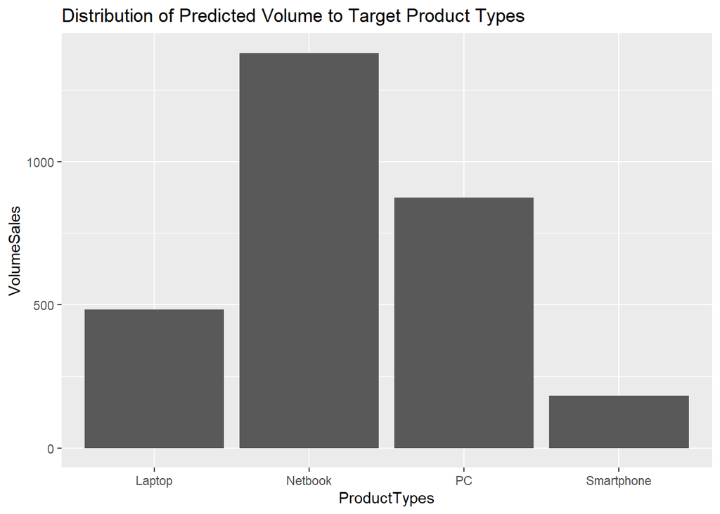

```r
library(ggplot2)
ggplot(data = NP_Products_Types_PredictionsFinal_Grouped_Products, aes(y = ProductTypes, x = VolumeSales)) + geom_bar(stat = 'identity') +
labs(title = 'Distribution of Predicted Volume to Target Product Types') +
coord_flip()
```

We have two metrics to analyze the errors associated to our predictions. These metrics are MAE and RMSE. Since we added all the specific product types, we can find the average error using the MAE for some close predicted values and use RMSE for extreme predicted values. In our analysis we observed that there are some cases where we could not achieve this because of the small data set used for analysis. Generally, there is a drawback to our solutions as there are no enough observations in our data set used for the training. The Model seems to be good despite the limitations, this conclusion is arrived at due to the value we got from our error metrics RMSE and MAE which are 184 and 88 respectively. These values seems to be small and smaller values denote better results.